# R Notebook

##Session 1 – Using dates and times

## Learning objectives

- Be able to manipulate dates and times in R
- Understand about time zones

iso 8601 standard - international standard for dealing with dates and times

Task - 5 mins - Take a few min and read about ISO 8601 standard, as we will be working with it a lot today. Answer the following questions:

- What order does ISO standard follow YYYY-MM-DD
- What is the minimum number of digits you can have in a year? Why? 4 digits - to avoid the year 2000 problem (potential computer errors relating to the formatting and storage of calendar data that might come from only storing the final two digits) -What clock system do the times use? 24 hour clock
- How many time formats does ISO standard have 4?
- What timezone are time and dates automatically represented in? UTC - Universal coordinated time
- How are combined date-times represented? You use the letter T as a delimiter, e.g. 2007-04-05T14:30

YYY = four digit year MM = two digit month DD = Two digit day of the month hh - two digits of hour in 24 hour time mm = two digits of minute ss = two digits of seconds s - one or more digits TZD

```r
as.Date("2022-08-21")
```

Dates are represented as integer numbers, so if you unclass them, it will tell you the number of days

```r
date_time1 <- as.POSIXct("2020-01-01 00:00:00")
date_time1
```

```r
date_time2 <- as.POSIXlt("2020-01-01 00:00:00")
date_time2
unclass(date_time2)

date_time2$mday
```

### Packages

```r
library(tidyverse)
library(lubridate)
```

Date conversion functions like ymd()

Date-time converting functions ymd_hms()

Extracting components year() wday() hour() etc.

timespans as.period()

```r
netflix <- read_csv("data/netflix.csv")
```

Date: “” Time: “”

```r
"2019-01-19"
```

```
[1] "2019-01-19"
```

```r
ymd("2019-01-19")
```

```
[1] "2019-01-19"
```

```r
mdy("January 9th, 2019")
```

```
[1] "2019-01-09"
```

```r
dmy("9-Jan-2019")
```

```
[1] "2019-01-09"
```

```r
ymd_hms("2019-01-19 10:08:26")
```

```
[1] "2019-01-19 10:08:26 UTC"
```

```r
ymd_hm("2019-01-19 10:08")
```

```
[1] "2019-01-19 10:08:00 UTC"
```

```r
ymd_h("2019-01-19 10")
```

```
[1] "2019-01-19 10:00:00 UTC"
```

Change column date added from character to a date using either dmy mdy or ymd

```r
netflix <- netflix %>%
  mutate(date_added = mdy(date_added))
```

## Extracting individual components

```r
month(netflix$date_added[1:5], label = TRUE, abbr = FALSE)
```

```
[1] August   December December November January
12 Levels: January < February < March < April < May < June < July < August < September < ... < December
```

```r
netflix <- netflix %>%
  mutate(day = day(date_added),
         month = month(date_added, label = TRUE, abbr = FALSE),
         year = year(date_added)
         )
```

Add a column weekday which is the day of the week thhe title was added

```r
netflix <- netflix %>%
  mutate(weekday = wday(date_added, label = TRUE))
```

## Calculating time spans

Three types of time span

Difftime: a datetime object that represents days Period: Represent a timespan like week/month/day - a discreet period Duration: represent an exact number of seconds

today() <- gives today’s date now() <- gives today’s date and the time inc seconds

```r
netflix<- netflix %>%
  mutate(time_difftime = today() - date_added)
```

```r
netflix <- netflix %>%
  mutate(time_period = as.period(today() - date_added),
         time_years = as.numeric(time_period, "years"),
         time_hours = as.numeric(time_period, "hours"),
         time_minutes = as.numeric(time_period, "minutes"),
         time_seconds = as.numeric(time_period, "seconds"))
netflix
```

| show_id | type | title | director | cast | country | date_added | release_year | rating | duration | listed_in | description | day | month | year | weekday | time_difftime | time_period | time_years | time_hours | time_minutes | time_seconds |
| --- | --- | --- | --- | --- | --- | --- | --- | --- | --- | --- | --- | --- | --- | --- | --- | --- | --- | --- | --- | --- | --- |
| s1 | TV Show | 3% | NA | João Miguel, Bianca Comparato, Michel Gomes, Rodolfo Valente, Vaneza Oliveira, Rafael Lozano, Viviane Porto, Mel Fronckowiak, Sergio Mamberti, Zezé Motta, Celso Frateschi | Brazil | 2020-08-14 | 2020 | TV-MA | 4 Seasons | International TV Shows, TV Dramas, TV Sci-Fi & Fantasy | In a future where the elite inhabit an island paradise far from the crowded slums, you get one chance to join the 3% saved from squalor. | 14 | August | 2020 | Fri | 739 days | 739d 0H 0M 0S | 2.023272 | 17736 | 1064160 | 63849600 |
| s2 | Movie | 7:19 | Jorge Michel Grau | Demián Bichir, Héctor Bonilla, Oscar Serrano, Azalia Ortiz, Octavio Michel, Carmen Beato | Mexico | 2016-12-23 | 2016 | TV-MA | 93 min | Dramas, International Movies | After a devastating earthquake hits Mexico City, trapped survivors from all walks of life wait to be rescued while trying desperately to stay alive. | 23 | December | 2016 | Fri | 2069 days | 2069d 0H 0M 0S | 5.664613 | 49656 | 2979360 | 178761600 |
| s3 | Movie | 23:59 | Gilbert Chan | Tedd Chan, Stella Chung, Henley Hii, Lawrence Koh, Tommy Kuan, Josh Lai, Mark Lee, Susan Leong, Benjamin Lim | Singapore | 2018-12-20 | 2011 | R | 78 min | Horror Movies, International Movies | When an army recruit is found dead, his fellow soldiers are forced to confront a terrifying secret that's haunting their jungle island training camp. | 20 | December | 2018 | Thu | 1342 days | 1342d 0H 0M 0S | 3.674196 | 32208 | 1932480 | 115948800 |
| s4 | Movie | 9 | Shane Acker | Elijah Wood, John C. Reilly, Jennifer Connelly, Christopher Plummer, Crispin Glover, Martin Landau, Fred Tatasciore, Alan Oppenheimer, Tom Kane | United States | 2017-11-16 | 2009 | PG-13 | 80 min | Action & Adventure, Independent Movies, Sci-Fi & Fantasy | In a postapocalyptic world, rag-doll robots hide in fear from dangerous machines out to exterminate them, until a brave newcomer joins the group. | 16 | November | 2017 | Thu | 1741 days | 1741d 0H 0M 0S | 4.766598 | 41784 | 2507040 | 150422400 |
| s5 | Movie | 21 | Robert Luketic | Jim Sturgess, Kevin Spacey, Kate Bosworth, Aaron Yoo, Liza Lapira, Jacob Pitts, Laurence Fishburne, Jack McGee, Josh Gad, Sam Golzari, Helen Carey, Jack Gilpin | United States | 2020-01-01 | 2008 | PG-13 | 123 min | Dramas | A brilliant group of students become card-counting experts with the intent of swindling millions out of Las Vegas casinos by playing blackjack. | 1 | January | 2020 | Wed | 965 days | 965d 0H 0M 0S | 2.642026 | 23160 | 1389600 | 83376000 |
| s6 | TV Show | 46 | Serdar Akar | Erdal Besikçioglu, Yasemin Allen, Melis Birkan, Saygin Soysal, Berkan Sal, Metin Belgin, Ayça Eren, Selin Uludogan, Özay Fecht, Suna Yildizoglu | Turkey | 2017-07-01 | 2016 | TV-MA | 1 Season | International TV Shows, TV Dramas, TV Mysteries | A genetics professor experiments with a treatment for his comatose sister that blends medical and shamanic cures, but unlocks a shocking side effect. | 1 | July | 2017 | Sat | 1879 days | 1879d 0H 0M 0S | 5.144422 | 45096 | 2705760 | 162345600 |
| s7 | Movie | 122 | Yasir Al Yasiri | Amina Khalil, Ahmed Dawood, Tarek Lotfy, Ahmed El Fishawy, Mahmoud Hijazi, Jihane Khalil, Asmaa Galal, Tara Emad | Egypt | 2020-06-01 | 2019 | TV-MA | 95 min | Horror Movies, International Movies | After an awful accident, a couple admitted to a grisly hospital are separated and must find each other to escape — before death finds them. | 1 | June | 2020 | Mon | 813 days | 813d 0H 0M 0S | 2.225873 | 19512 | 1170720 | 70243200 |
| s8 | Movie | 187 | Kevin Reynolds | Samuel L. Jackson, John Heard, Kelly Rowan, Clifton Collins Jr., Tony Plana | United States | 2019-11-01 | 1997 | R | 119 min | Dramas | After one of his high school students attacks him, dedicated teacher Trevor Garfield grows weary of the gang warfare in the New York City school system and moves to California to teach there, thinking… | 1 | November | 2019 | Fri | 1026 days | 1026d 0H 0M 0S | 2.809035 | 24624 | 1477440 | 88646400 |
| s9 | Movie | 706 | Shravan Kumar | Divya Dutta, Atul Kulkarni, Mohan Agashe, Anupam Shyam, Raayo S. Bakhirta, Yashvit Sancheti, Greeva Kansara, Archan Trivedi, Rajiv Pathak | India | 2019-04-01 | 2019 | TV-14 | 118 min | Horror Movies, International Movies | When a doctor goes missing, his psychiatrist wife treats the bizarre medical condition of a psychic patient, who knows much more than he's leading on. | 1 | April | 2019 | Mon | 1240 days | 1240d 0H 0M 0S | 3.394935 | 29760 | 1785600 | 107136000 |
| s10 | Movie | 1920 | Vikram Bhatt | Rajneesh Duggal, Adah Sharma, Indraneil Sengupta, Anjori Alagh, Rajendranath Zutshi, Vipin Sharma, Amin Hajee, Shri Vallabh Vyas | India | 2017-12-15 | 2008 | TV-MA | 143 min | Horror Movies, International Movies, Thrillers | An architect and his wife move into a castle that is slated to become a luxury hotel. But something inside is determined to stop the renovation. | 15 | December | 2017 | Fri | 1712 days | 1712d 0H 0M 0S | 4.687201 | 41088 | 2465280 | 147916800 |

[output cut: 990 more lines]

### Subtracting periods from dates

For example, say we found out that Netflix promotes releases on their web app for 2 weeks before the show is released and then takes them down after 4 months

```r
netflix <- netflix %>%
  mutate(promo_date = date_added - weeks(2),
         removal_date = date_added +months(4))

netflix %>%
  select(date_added, promo_date, removal_date)
```

| date_added | promo_date | removal_date |
| --- | --- | --- |
| 2020-08-14 | 2020-07-31 | 2020-12-14 |
| 2016-12-23 | 2016-12-09 | 2017-04-23 |
| 2018-12-20 | 2018-12-06 | 2019-04-20 |
| 2017-11-16 | 2017-11-02 | 2018-03-16 |
| 2020-01-01 | 2019-12-18 | 2020-05-01 |
| 2017-07-01 | 2017-06-17 | 2017-11-01 |
| 2020-06-01 | 2020-05-18 | 2020-10-01 |
| 2019-11-01 | 2019-10-18 | 2020-03-01 |
| 2019-04-01 | 2019-03-18 | 2019-08-01 |
| 2017-12-15 | 2017-12-01 | 2018-04-15 |

[output cut: 990 more lines]

```r
netflix %>%
  mutate(time_period = as.period(today() - date_added),
         weeks = as.numeric(time_period, "weeks"))
```

| show_id | type | title | director | cast | country | date_added | release_year | rating | duration | listed_in | description | day | month | year | weekday | time_difftime | time_period | time_years | time_hours | time_minutes | time_seconds | promo_date | removal_date | weeks |
| --- | --- | --- | --- | --- | --- | --- | --- | --- | --- | --- | --- | --- | --- | --- | --- | --- | --- | --- | --- | --- | --- | --- | --- | --- |
| s1 | TV Show | 3% | NA | João Miguel, Bianca Comparato, Michel Gomes, Rodolfo Valente, Vaneza Oliveira, Rafael Lozano, Viviane Porto, Mel Fronckowiak, Sergio Mamberti, Zezé Motta, Celso Frateschi | Brazil | 2020-08-14 | 2020 | TV-MA | 4 Seasons | International TV Shows, TV Dramas, TV Sci-Fi & Fantasy | In a future where the elite inhabit an island paradise far from the crowded slums, you get one chance to join the 3% saved from squalor. | 14 | August | 2020 | Fri | 739 days | 739d 0H 0M 0S | 2.023272 | 17736 | 1064160 | 63849600 | 2020-07-31 | 2020-12-14 | 105.57143 |
| s2 | Movie | 7:19 | Jorge Michel Grau | Demián Bichir, Héctor Bonilla, Oscar Serrano, Azalia Ortiz, Octavio Michel, Carmen Beato | Mexico | 2016-12-23 | 2016 | TV-MA | 93 min | Dramas, International Movies | After a devastating earthquake hits Mexico City, trapped survivors from all walks of life wait to be rescued while trying desperately to stay alive. | 23 | December | 2016 | Fri | 2069 days | 2069d 0H 0M 0S | 5.664613 | 49656 | 2979360 | 178761600 | 2016-12-09 | 2017-04-23 | 295.57143 |
| s3 | Movie | 23:59 | Gilbert Chan | Tedd Chan, Stella Chung, Henley Hii, Lawrence Koh, Tommy Kuan, Josh Lai, Mark Lee, Susan Leong, Benjamin Lim | Singapore | 2018-12-20 | 2011 | R | 78 min | Horror Movies, International Movies | When an army recruit is found dead, his fellow soldiers are forced to confront a terrifying secret that's haunting their jungle island training camp. | 20 | December | 2018 | Thu | 1342 days | 1342d 0H 0M 0S | 3.674196 | 32208 | 1932480 | 115948800 | 2018-12-06 | 2019-04-20 | 191.71429 |
| s4 | Movie | 9 | Shane Acker | Elijah Wood, John C. Reilly, Jennifer Connelly, Christopher Plummer, Crispin Glover, Martin Landau, Fred Tatasciore, Alan Oppenheimer, Tom Kane | United States | 2017-11-16 | 2009 | PG-13 | 80 min | Action & Adventure, Independent Movies, Sci-Fi & Fantasy | In a postapocalyptic world, rag-doll robots hide in fear from dangerous machines out to exterminate them, until a brave newcomer joins the group. | 16 | November | 2017 | Thu | 1741 days | 1741d 0H 0M 0S | 4.766598 | 41784 | 2507040 | 150422400 | 2017-11-02 | 2018-03-16 | 248.71429 |
| s5 | Movie | 21 | Robert Luketic | Jim Sturgess, Kevin Spacey, Kate Bosworth, Aaron Yoo, Liza Lapira, Jacob Pitts, Laurence Fishburne, Jack McGee, Josh Gad, Sam Golzari, Helen Carey, Jack Gilpin | United States | 2020-01-01 | 2008 | PG-13 | 123 min | Dramas | A brilliant group of students become card-counting experts with the intent of swindling millions out of Las Vegas casinos by playing blackjack. | 1 | January | 2020 | Wed | 965 days | 965d 0H 0M 0S | 2.642026 | 23160 | 1389600 | 83376000 | 2019-12-18 | 2020-05-01 | 137.85714 |
| s6 | TV Show | 46 | Serdar Akar | Erdal Besikçioglu, Yasemin Allen, Melis Birkan, Saygin Soysal, Berkan Sal, Metin Belgin, Ayça Eren, Selin Uludogan, Özay Fecht, Suna Yildizoglu | Turkey | 2017-07-01 | 2016 | TV-MA | 1 Season | International TV Shows, TV Dramas, TV Mysteries | A genetics professor experiments with a treatment for his comatose sister that blends medical and shamanic cures, but unlocks a shocking side effect. | 1 | July | 2017 | Sat | 1879 days | 1879d 0H 0M 0S | 5.144422 | 45096 | 2705760 | 162345600 | 2017-06-17 | 2017-11-01 | 268.42857 |
| s7 | Movie | 122 | Yasir Al Yasiri | Amina Khalil, Ahmed Dawood, Tarek Lotfy, Ahmed El Fishawy, Mahmoud Hijazi, Jihane Khalil, Asmaa Galal, Tara Emad | Egypt | 2020-06-01 | 2019 | TV-MA | 95 min | Horror Movies, International Movies | After an awful accident, a couple admitted to a grisly hospital are separated and must find each other to escape — before death finds them. | 1 | June | 2020 | Mon | 813 days | 813d 0H 0M 0S | 2.225873 | 19512 | 1170720 | 70243200 | 2020-05-18 | 2020-10-01 | 116.14286 |
| s8 | Movie | 187 | Kevin Reynolds | Samuel L. Jackson, John Heard, Kelly Rowan, Clifton Collins Jr., Tony Plana | United States | 2019-11-01 | 1997 | R | 119 min | Dramas | After one of his high school students attacks him, dedicated teacher Trevor Garfield grows weary of the gang warfare in the New York City school system and moves to California to teach there, thinking… | 1 | November | 2019 | Fri | 1026 days | 1026d 0H 0M 0S | 2.809035 | 24624 | 1477440 | 88646400 | 2019-10-18 | 2020-03-01 | 146.57143 |
| s9 | Movie | 706 | Shravan Kumar | Divya Dutta, Atul Kulkarni, Mohan Agashe, Anupam Shyam, Raayo S. Bakhirta, Yashvit Sancheti, Greeva Kansara, Archan Trivedi, Rajiv Pathak | India | 2019-04-01 | 2019 | TV-14 | 118 min | Horror Movies, International Movies | When a doctor goes missing, his psychiatrist wife treats the bizarre medical condition of a psychic patient, who knows much more than he's leading on. | 1 | April | 2019 | Mon | 1240 days | 1240d 0H 0M 0S | 3.394935 | 29760 | 1785600 | 107136000 | 2019-03-18 | 2019-08-01 | 177.14286 |
| s10 | Movie | 1920 | Vikram Bhatt | Rajneesh Duggal, Adah Sharma, Indraneil Sengupta, Anjori Alagh, Rajendranath Zutshi, Vipin Sharma, Amin Hajee, Shri Vallabh Vyas | India | 2017-12-15 | 2008 | TV-MA | 143 min | Horror Movies, International Movies, Thrillers | An architect and his wife move into a castle that is slated to become a luxury hotel. But something inside is determined to stop the renovation. | 15 | December | 2017 | Fri | 1712 days | 1712d 0H 0M 0S | 4.687201 | 41088 | 2465280 | 147916800 | 2017-12-01 | 2018-04-15 | 244.57143 |

[output cut: 990 more lines]

Duration: represent an exact number of seconds

```r
netflix <- netflix %>%
  mutate(time_duration = as.duration(today() - date_added))

netflix %>%
  select(starts_with("time"))
```

| time_difftime | time_period | time_years | time_hours | time_minutes | time_seconds | time_duration |
| --- | --- | --- | --- | --- | --- | --- |
| 739 days | 739d 0H 0M 0S | 2.023272 | 17736 | 1064160 | 63849600 | 63849600s (~2.02 years) |
| 2069 days | 2069d 0H 0M 0S | 5.664613 | 49656 | 2979360 | 178761600 | 178761600s (~5.66 years) |
| 1342 days | 1342d 0H 0M 0S | 3.674196 | 32208 | 1932480 | 115948800 | 115948800s (~3.67 years) |
| 1741 days | 1741d 0H 0M 0S | 4.766598 | 41784 | 2507040 | 150422400 | 150422400s (~4.77 years) |
| 965 days | 965d 0H 0M 0S | 2.642026 | 23160 | 1389600 | 83376000 | 83376000s (~2.64 years) |
| 1879 days | 1879d 0H 0M 0S | 5.144422 | 45096 | 2705760 | 162345600 | 162345600s (~5.14 years) |
| 813 days | 813d 0H 0M 0S | 2.225873 | 19512 | 1170720 | 70243200 | 70243200s (~2.23 years) |
| 1026 days | 1026d 0H 0M 0S | 2.809035 | 24624 | 1477440 | 88646400 | 88646400s (~2.81 years) |
| 1240 days | 1240d 0H 0M 0S | 3.394935 | 29760 | 1785600 | 107136000 | 107136000s (~3.39 years) |
| 1712 days | 1712d 0H 0M 0S | 4.687201 | 41088 | 2465280 | 147916800 | 147916800s (~4.69 years) |

[output cut: 990 more lines]

dseconds() dminutes() dhours() ddays() dweeks() dmonths() dyears()

What date is a year after the 10th of January 2020?

Is it:

```r
ymd(20200110) + years(1)
ymd(20200110) + dyears(1) #adds on 365 days exactly, so one day less b/c of leap year in 2020
```

## Understanding timezones

```r
OlsonNames()

ymd_hms("2023-09-13 10:22:01", tz = "Atlantic/Faeroe")


netflix %>%
  mutate(date_tz_1 = force_tz(date_added, tzone = "Asia/Singapore"),
         date_tz_2 = with_tz(date_added, tzone = "Asia/Singapore")) %>%
  select(date_added, date_tz_1, date_tz_2)
```

What is the difference between the two functions?

force_tz just adds a time zone, it doesn’t change the date or time. with_tz figures out what the date and time would be if you moved from the current time zone to the one asked for

## Session 3 – Introduction to time series

### Learning objectives

-Know what time series data looks like -Understand some of the key components of time series data -See some examples of the application of time series data -Understand why familiarity with time series data is important

```r
library(tsibble)
library(tsibbledata)
```

“as_tsibble()”

## “tsibble”

**index**: time component **Key** : identifies the underlying structure of the data : in conjuction with the **index** uniquely identities each individual row

```r
vic_elec
```

```r
index(vic_elec)
index_var(vic_elec)

key(vic_elec)
key_vars(vic_elec)

interval(vic_elec)
```

```r
vic_elec %>%
  select(Time, Demand, Temperature)
```

```r
vic_elec %>%
  filter(!Holiday)

vic_elec %>%
  filter(Time < "2012-01-01 01:00:00")

vic_elec %>%
  filter(Time < as.POSIXct("2012-01-01 01:00:00", tz = "Australia/Melbourne"))

vic_elec %>%
  filter(Time < as.Date("2012-01-02"))

vic_elec %>%
  filter_index("2012-01")
```

```r
vic_elec <- vic_elec %>%
  mutate(year = lubridate::year(Date))
```

```r
vic_elec %>%
  select(year, Temperature) %>%
  group_by(year) %>%
  summarise(mean_temp = mean(Temperature))

vic_elec %>%
  select(year, Temperature) %>%
  index_by(year) %>%
  summarise(mean_temp = mean(Temperature))

vic_elec %>%
  mutate(date = as_date(Time), .after = Time)


vic_elec %>%
  index_by(as_date(Time)) %>%
  summarise(mean_temp = mean(Temperature))
```

## “tsibble” and “ggplot2”

```r
vic_elec %>%
  filter(!Holiday) %>%
  ggplot() +
  geom_line(aes(x = Time, y = Temperature))
```

Useful for extractign different components of the time series data

```r
floor_date()
ceiling_date()

yearweek()
yearmonth()
yearquarter()
```

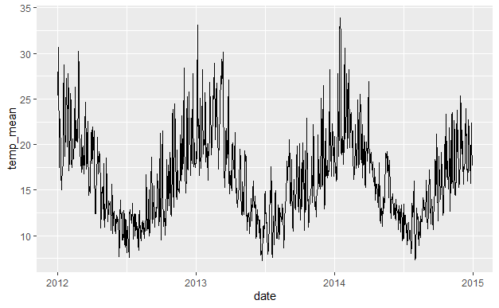

```r
elec_date <- vic_elec %>%
  index_by(date = as_date(Time)) %>%
  summarise(temp_mean = mean(Temperature, na.rm = TRUE))

elec_date %>%
  ggplot(aes(date, temp_mean)) +
  geom_line()
```

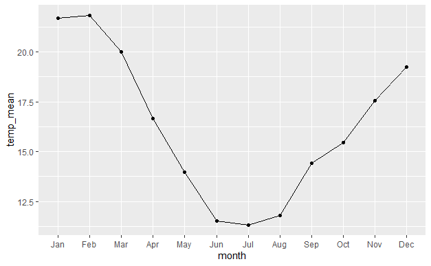

```r
elec_month <- vic_elec %>%
  index_by(month = month(Time, label = TRUE)) %>%
  summarise(temp_mean = mean(Temperature, na.rm = TRUE))

elec_month %>%
  ggplot(aes(month, temp_mean)) +
  geom_point() +
  geom_line(group = 1)
```

```r
elec_year <- vic_elec %>%
  index_by(year = year(Time)) %>%
  summarise(temp_mean = mean(Temperature, na.rm = TRUE))

elec_year
```

| year | temp_mean |
| --- | --- |
| 2012 | 15.95318 |
| 2013 | 16.33727 |
| 2014 | 16.50562 |

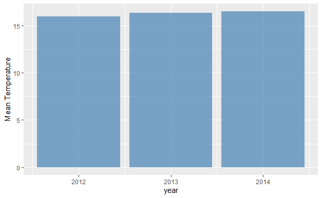

```r
elec_year %>%
  ggplot(aes(x = year, y = temp_mean)) +
  geom_col(fill = "steelblue", alpha = 0.7) +
  ylab("Mean Temperature")+
  xlab("year")
```

## Rolling windows

```r
library(slider)
library(feasts)
```

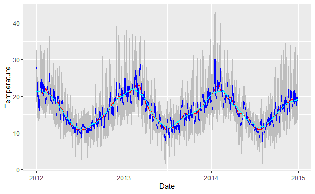

```r
elec_rolling <- vic_elec %>%
  mutate(
    temp_moving_avg = slide_dbl(
      .x = Temperature,
      .f = ~ mean(., na.rm = TRUE),
      .before = 1000,
      .after = 1000,
      .complete = TRUE
    ),
    temp_mvn_avg_1c = slide_dbl(
      .x = Temperature,
      .f = ~ mean(., na.rm = TRUE),
      .before = 100,
      .after = 100
    ),
    temp_mvn_avg_comp = slide_dbl(
       .x = Temperature,
      .f = ~ mean(., na.rm = TRUE),
      .before = 2000,
      .after = 2000,
      .complete = FALSE
    )
  )

ggplot(elec_rolling) +
  geom_line(aes(Date, Temperature), colour = "grey") +
geom_line(aes(Date, temp_moving_avg), colour = "red") +
geom_line(aes(Date, temp_mvn_avg_1c), colour = "blue") +
geom_line(aes(Date, temp_mvn_avg_comp), colour = "cyan")
```

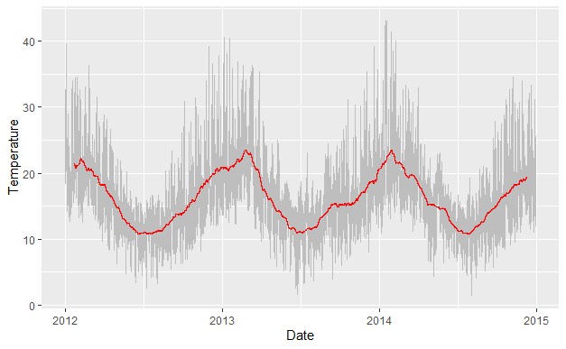

```r
ggplot(elec_rolling) +
  geom_line(aes(x = Date,
                y = Temperature), colour = "grey") +
  geom_line(aes(x = Date,
                y = temp_moving_avg), colour = "red")
```

```r
NA
NA
```

## “feasts”

```r
tourism
```

| Quarter | Region | State | Purpose | Trips |
| --- | --- | --- | --- | --- |
| 1998 Q1 | Adelaide | South Australia | Business | 135.0776903 |
| 1998 Q2 | Adelaide | South Australia | Business | 109.9873160 |
| 1998 Q3 | Adelaide | South Australia | Business | 166.0346866 |
| 1998 Q4 | Adelaide | South Australia | Business | 127.1604643 |
| 1999 Q1 | Adelaide | South Australia | Business | 137.4485333 |
| 1999 Q2 | Adelaide | South Australia | Business | 199.9125861 |
| 1999 Q3 | Adelaide | South Australia | Business | 169.3550898 |
| 1999 Q4 | Adelaide | South Australia | Business | 134.3579372 |
| 2000 Q1 | Adelaide | South Australia | Business | 154.0343980 |
| 2000 Q2 | Adelaide | South Australia | Business | 168.7763637 |

[output cut: 990 more lines]

```r
index_var(tourism)
```

```
[1] "Quarter"
```

```r
key_vars(tourism)
```

```
[1] "Region"  "State"   "Purpose"
```

```r
tourism %>%
  distinct(Purpose)
```

| Purpose |
| --- |
| Business |
| Holiday |
| Other |
| Visiting |

```r
tourism %>%
  distinct(State)
```

| State |
| --- |
| South Australia |
| Northern Territory |
| Western Australia |
| Victoria |
| New South Wales |
| Queensland |
| ACT |
| Tasmania |

```r
tourism %>%
  distinct(Region)
```

| Region |
| --- |
| Adelaide |
| Adelaide Hills |
| Alice Springs |
| Australia's Coral Coast |
| Australia's Golden Outback |
| Australia's North West |
| Australia's South West |
| Ballarat |
| Barkly |
| Barossa |

[output cut: 66 more lines]

```r
tourism %>%
  distinct(State, Region, Purpose)
```

| Region | State | Purpose |
| --- | --- | --- |
| Adelaide | South Australia | Business |
| Adelaide | South Australia | Holiday |
| Adelaide | South Australia | Other |
| Adelaide | South Australia | Visiting |
| Adelaide Hills | South Australia | Business |
| Adelaide Hills | South Australia | Holiday |
| Adelaide Hills | South Australia | Other |
| Adelaide Hills | South Australia | Visiting |
| Alice Springs | Northern Territory | Business |
| Alice Springs | Northern Territory | Holiday |

[output cut: 294 more lines]

```r
holidays <- tourism %>%
  filter(Purpose %in% c("Holiday", "Business")) %>%
  group_by(State) %>%
  summarise(Trips = sum(Trips))

holidays
```

| State | Quarter | Trips |
| --- | --- | --- |
| ACT | 1998 Q1 | 346.4167 |
| ACT | 1998 Q2 | 226.7033 |
| ACT | 1998 Q3 | 240.2448 |
| ACT | 1998 Q4 | 272.1712 |
| ACT | 1999 Q1 | 203.3042 |
| ACT | 1999 Q2 | 353.7018 |
| ACT | 1999 Q3 | 286.7766 |
| ACT | 1999 Q4 | 376.6391 |
| ACT | 2000 Q1 | 263.6565 |
| ACT | 2000 Q2 | 356.8234 |

[output cut: 630 more lines]

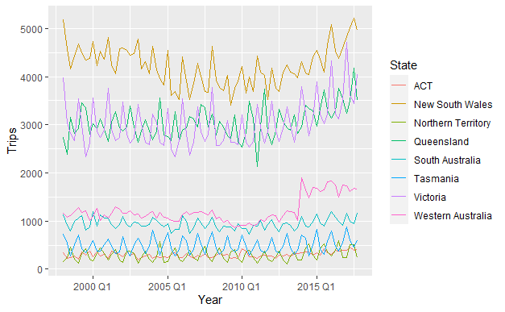

```r
holidays %>%
autoplot(Trips) +
  xlab("Year")
```

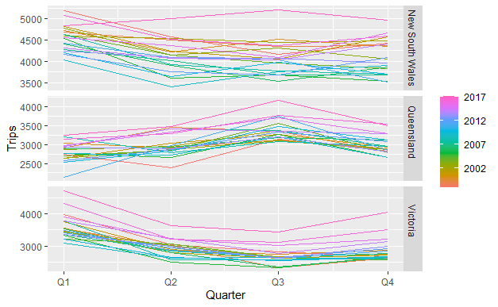

```r
holidays %>%
  filter(State %in% c("Queensland", "New South Wales", "Victoria")) %>%
  gg_season(Trips)
```

```r
holidays %>%
  filter(State %in% c("Queensland", "New South Wales", "Victoria")) %>%
  gg_subseries(Trips)
```

Do the hard work for your audience And make it nice for the audience